# 新加坡组屋转售价格数据分析报告

### 2.5 数据概览

在数据清洗和整理后，我们再次概览数据，确保所有变换都按预期进行。

```r
# 再次预览数据集的前几行
head(data)
```

```
##   year       town flat_type block          street_name storey_range
## 1 2017 ANG MO KIO    2 ROOM   406 ANG MO KIO AVENUE 10     10 TO 12
## 2 2017 ANG MO KIO    3 ROOM   108  ANG MO KIO AVENUE 4     01 TO 03
## 3 2017 ANG MO KIO    3 ROOM   602  ANG MO KIO AVENUE 5     01 TO 03
## 4 2017 ANG MO KIO    3 ROOM   465 ANG MO KIO AVENUE 10     04 TO 06
## 5 2017 ANG MO KIO    3 ROOM   601  ANG MO KIO AVENUE 5     01 TO 03
## 6 2017 ANG MO KIO    3 ROOM   150  ANG MO KIO AVENUE 5     01 TO 03
##   floor_area_sqm remaining_lease_years resale_price storey_range_category
## 1             44                    61       232000       Low-Mid (07-12)
## 2             67                    60       250000           Low (01-06)
## 3             67                    62       262000           Low (01-06)
## 4             68                    62       265000           Low (01-06)
## 5             67                    62       265000           Low (01-06)
## 6             68                    63       275000           Low (01-06)
##   distance_from_expressway
## 1                    >500m
## 2                    >500m
## 3                    >500m
## 4                 151-300m
## 5                    >500m
## 6                    >500m
```

```r
# 查看数据集的结构
str(data)
```

```
## 'data.frame':    220971 obs. of  11 variables:
##  $ year                    : num  2017 2017 2017 2017 2017 ...
##  $ town                    : Factor w/ 26 levels "ANG MO KIO","BEDOK",..: 1 1 1 1 1 1 1 1 1 1 ...
##  $ flat_type               : Factor w/ 7 levels "1 ROOM","2 ROOM",..: 2 3 3 3 3 3 3 3 3 3 ...
##  $ block                   : chr  "406" "108" "602" "465" ...
##  $ street_name             : chr  "ANG MO KIO AVENUE 10" "ANG MO KIO AVENUE 4" "ANG MO KIO AVENUE 5" "ANG MO KIO AVENUE 10" ...
##  $ storey_range            : chr  "10 TO 12" "01 TO 03" "01 TO 03" "04 TO 06" ...
##  $ floor_area_sqm          : num  44 67 67 68 67 68 68 67 68 67 ...
##  $ remaining_lease_years   : int  61 60 62 62 62 63 61 58 61 61 ...
##  $ resale_price            : num  232000 250000 262000 265000 265000 275000 280000 285000 285000 285000 ...
##  $ storey_range_category   : chr  "Low-Mid (07-12)" "Low (01-06)" "Low (01-06)" "Low (01-06)" ...
##  $ distance_from_expressway: chr  ">500m" ">500m" ">500m" "151-300m" ...
```

```r
# 获取数据集的摘要统计信息
summary(data)
```

```
##       year               town                   flat_type
##  Min.   :2015   SENGKANG   : 17787   1 ROOM          :   74
##  1st Qu.:2017   WOODLANDS  : 15654   2 ROOM          : 3659
##  Median :2020   PUNGGOL    : 15140   3 ROOM          :53299
##  Mean   :2020   JURONG WEST: 15089   4 ROOM          :92796
##  3rd Qu.:2022   TAMPINES   : 15027   5 ROOM          :54543
##  Max.   :2024   YISHUN     : 14700   EXECUTIVE       :16519
##                 (Other)    :127574   MULTI-GENERATION:   81
##     block           street_name        storey_range       floor_area_sqm
##  Length:220971      Length:220971      Length:220971      Min.   : 31.00
##  Class :character   Class :character   Class :character   1st Qu.: 82.00
##  Mode  :character   Mode  :character   Mode  :character   Median : 94.00
##                                                           Mean   : 97.18
##                                                           3rd Qu.:112.00
##                                                           Max.   :366.70
##
##  remaining_lease_years  resale_price     storey_range_category
##  Min.   :41.00         Min.   : 140000   Length:220971
##  1st Qu.:63.00         1st Qu.: 365000   Class :character
##  Median :74.00         Median : 458000   Mode  :character
##  Mean   :74.49         Mean   : 490867
##  3rd Qu.:86.00         3rd Qu.: 585000
##  Max.   :98.00         Max.   :1588000
##
##  distance_from_expressway
##  Length:220971
##  Class :character
##  Mode  :character
##
##
##
##
```

### 2.6 数据保存

完成数据清洗和整理后，我们可以选择将清洗后的数据保存为新的CSV文件，以便后续分析使用。

```r
# 保存清洗后的数据集
write.csv(data, "cleaned_data.csv", row.names = FALSE)
```

## 模块3：深入洞察新加坡住房市场数据

### 3.1 数据洞察

在完成数据清洗后，我们进入**数据洞察**阶段，旨在深入理解新加坡住房市场的特征和趋势。

### 3.1.1 数值变量分析

我们将分析数值变量，如**楼层面积**、**剩余租期**和**二手房价格**，以揭示其分布和关键统计指标。

```r
# 楼层面积关键统计指标
floor_area_summary <- summary(data$floor_area_sqm)

# 二手房价格关键统计指标
resale_price_summary <- summary(data$resale_price)

# 剩余租期关键统计指标
lease_years_summary <- summary(data$remaining_lease_years)

floor_area_summary
```

```
##    Min. 1st Qu.  Median    Mean 3rd Qu.    Max.
##   31.00   82.00   94.00   97.18  112.00  366.70
```

```r
resale_price_summary
```

```
##    Min. 1st Qu.  Median    Mean 3rd Qu.    Max.
##  140000  365000  458000  490867  585000 1588000
```

```r
lease_years_summary
```

```
##    Min. 1st Qu.  Median    Mean 3rd Qu.    Max.
##   41.00   63.00   74.00   74.49   86.00   98.00
```

### 3.1.2 分类变量分析

我们将分析分类变量，如**镇名**、**房型**、**楼层范围**和**距离高速公路**的距离，以了解不同类别的分布情况。

```r
# 镇名频数分布
town_frequency <- table(data$town)

# 房型频数分布
flat_type_frequency <- table(data$flat_type)

# 楼层范围频数分布
storey_range_frequency <- table(data$storey_range_category)

# 距离高速公路距离频数分布
distance_frequency <- table(data$distance_from_expressway)

town_frequency
```

```
##
##      ANG MO KIO           BEDOK          BISHAN     BUKIT BATOK     BUKIT MERAH
##            9436           12146            4028            8656            8428
##   BUKIT PANJANG     BUKIT TIMAH    CENTRAL AREA   CHOA CHU KANG        CLEMENTI
##            8085             551            1892           10190            5071
##         GEYLANG         HOUGANG     JURONG EAST     JURONG WEST KALLANG/WHAMPOA
##            5541           11179            4604           15089            6686
##   MARINE PARADE       PASIR RIS         PUNGGOL      QUEENSTOWN       SEMBAWANG
##            1347            6638           15140            6051            6025
##        SENGKANG       SERANGOON        TAMPINES       TOA PAYOH       WOODLANDS
##           17787            4191           15027            6829           15654
##          YISHUN
##           14700
```

```r
flat_type_frequency
```

```
##
##           1 ROOM           2 ROOM           3 ROOM           4 ROOM
##               74             3659            53299            92796
##           5 ROOM        EXECUTIVE MULTI-GENERATION
##            54543            16519               81
```

```r
storey_range_frequency
```

```
##
##    High (19-30) Low-Mid (07-12)     Low (01-06)     Mid (13-18) Very High (>30)
##            9841           88059           90737           30385            1949
```

```r
distance_frequency
```

```
##
##    <=50m    >500m 101-150m 151-300m 301-500m  51-100m
##     3584   190701     6296     7832     3948     8610
```

### 3.2 数据视觉呈现

视觉呈现是数据洞察的关键环节，我们将通过图表直观展示新加坡住房市场的数据特征。

### 3.2.1 数值变量视觉化

我们将使用直方图和箱线图展示楼层面积、二手房价格和剩余租期的分布特征。

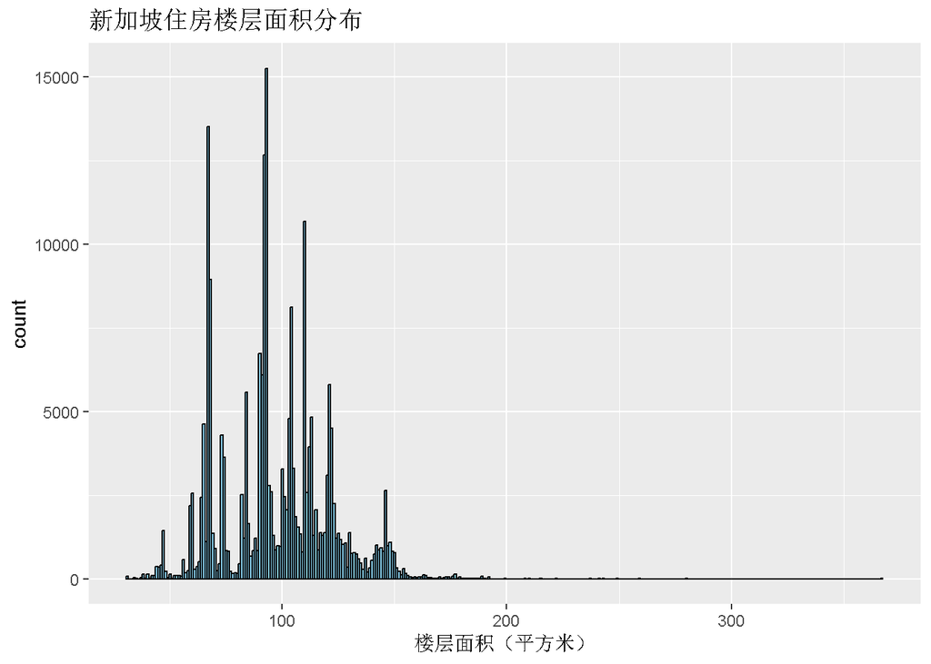

```r
# 加载ggplot2包
library(ggplot2)

# 楼层面积直方图
ggplot(data, aes(x = floor_area_sqm)) +
  geom_histogram(binwidth = 1, fill = "skyblue", color = "black") +
  ggtitle("新加坡住房楼层面积分布") +
  xlab("楼层面积（平方米）")
```

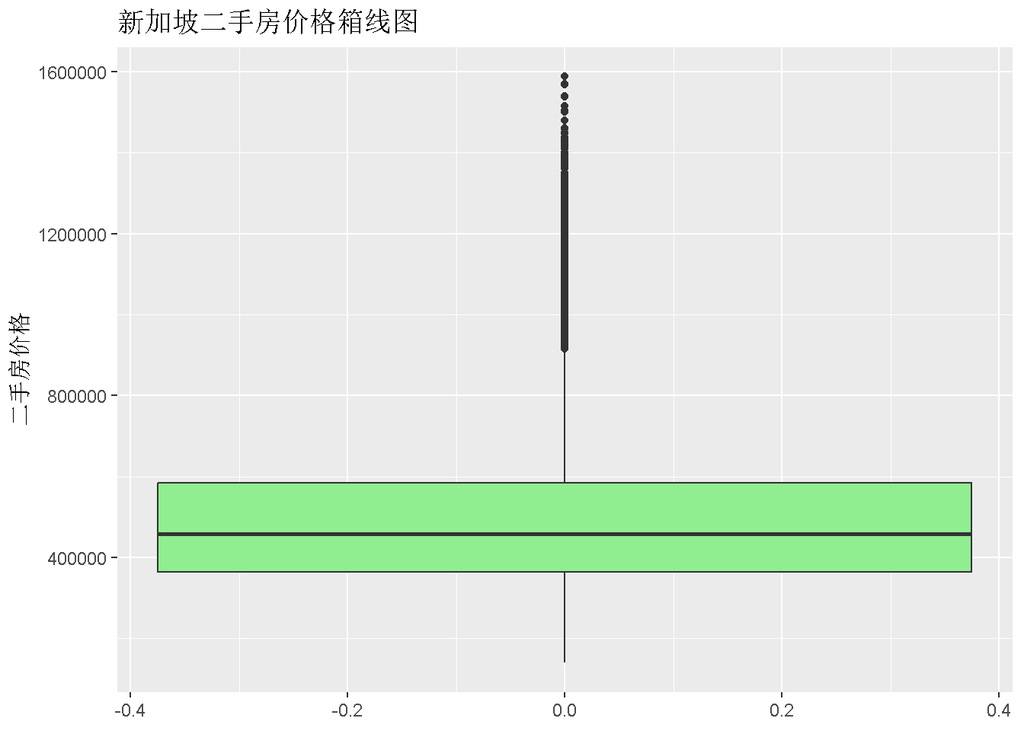

```r
# 二手房价格箱线图
ggplot(data, aes(y = resale_price)) +
  geom_boxplot(fill = "lightgreen") +
  ggtitle("新加坡二手房价格箱线图") +
  ylab("二手房价格")
```

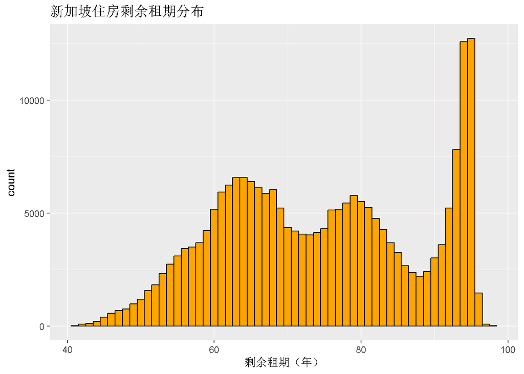

```r
# 剩余租期直方图
ggplot(data, aes(x = remaining_lease_years)) +
  geom_histogram(binwidth = 1, fill = "orange", color = "black") +
  ggtitle("新加坡住房剩余租期分布") +
  xlab("剩余租期（年）")
```

可以看到新加坡目前租房状况呈现三个特点  
一、住房面积以中型为主  
二、 二手房价格普遍居高不下  
三、 房屋剩余租期一般偏长

### 3.2.2 分类变量视觉化

为了更进一步的进行数据分析，我们需要探求更多因素的分布状况，所以 我们将使用条形图展示房型的分布情况。

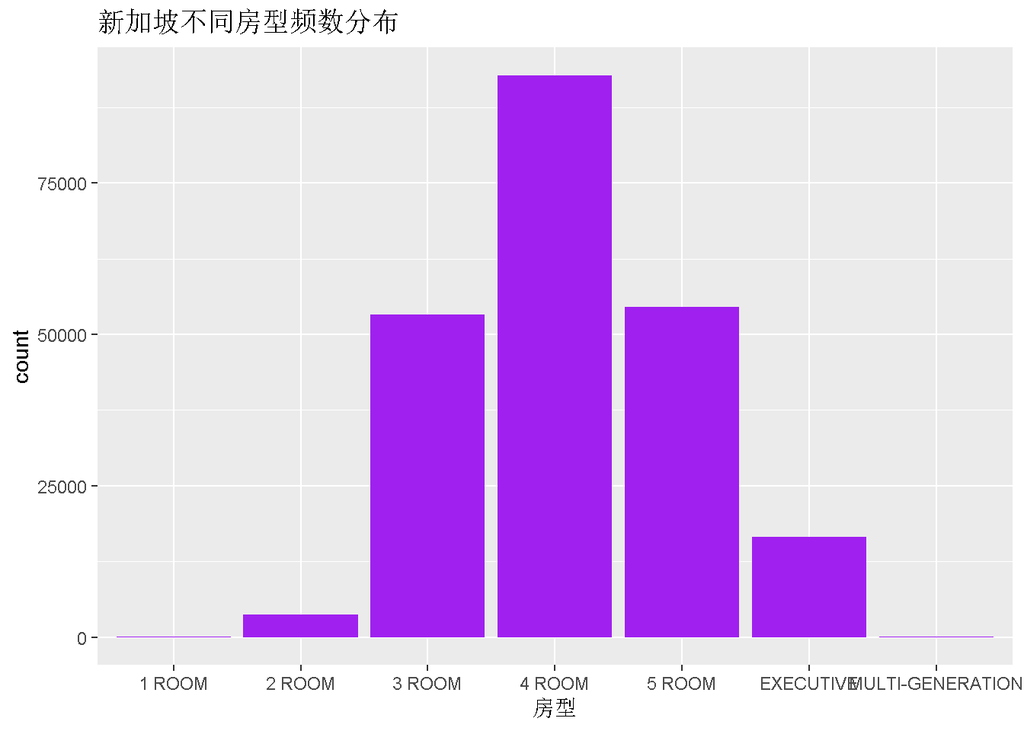

```r
# 房型频数分布条形图
ggplot(data, aes(x = flat_type)) +
  geom_bar(fill = "purple") +
  ggtitle("新加坡不同房型频数分布") +
  xlab("房型")
```

## 模块4：相关性分析

### 4.1 相关性分析简介

在房地产市场中，了解不同特征与房屋转售价格之间的关系至关重要。本模块旨在通过计算和可视化各变量与转售价格之间的相关性，识别潜在的影响因素。

### 4.2 计算相关性

我们首先计算数据集中各数值变量与转售价格之间的皮尔逊相关系数。

```r
# 加载所需库
library(ggplot2)
library(dplyr)
# 读取数据集
data <- read.csv("a.csv")
# 选择数值型变量
numeric_data <- data %>% select_if(is.numeric)

# 计算相关性
correlation_matrix <- cor(numeric_data, use = "complete.obs")

# 提取与resale_price的相关性
resale_price_correlation <- correlation_matrix["resale_price", ]

# 打印相关性
print(resale_price_correlation)
```

```
##                  year        floor_area_sqm remaining_lease_years
##             0.3155725             0.5952850             0.3206110
##          resale_price
##             1.0000000
```

### 4.3 可视化相关性

为了更直观地理解这些相关性，我们使用ggplot2包创建散点图和热力图。

### 4.3.1 散点图示例

以下是一个散点图示例，展示楼层面积与转售价格的关系。

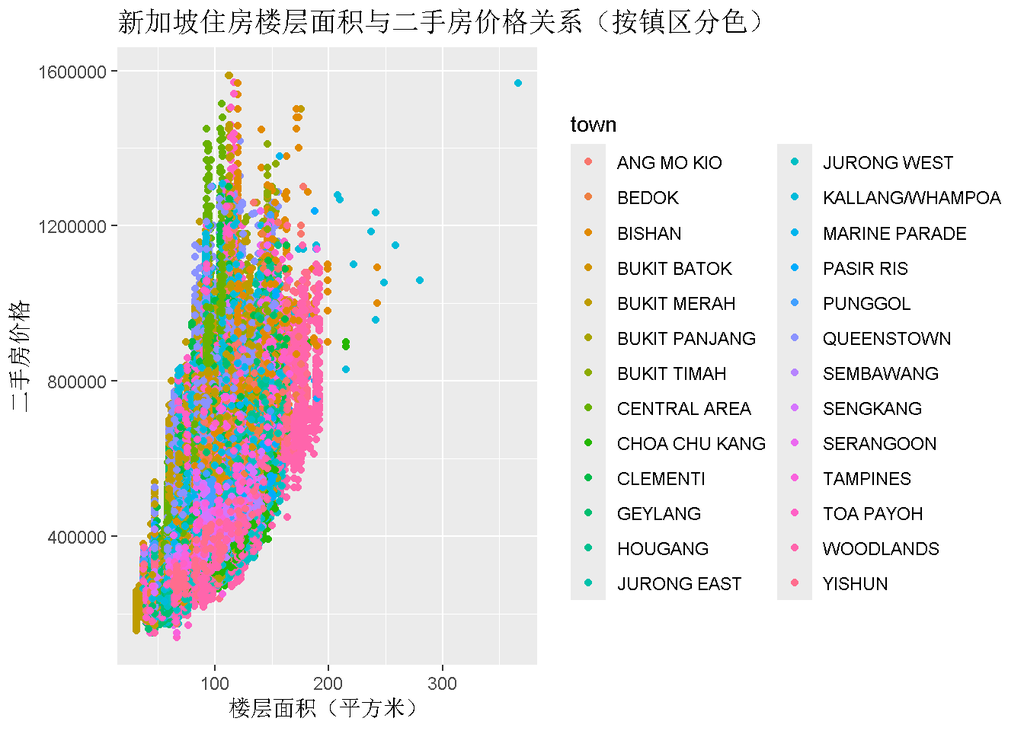

```r
# 楼层面积与二手房价格关系图（按镇区分色）
ggplot(data, aes(x = floor_area_sqm, y = resale_price, color = town)) +
  geom_point() +
  ggtitle("新加坡住房楼层面积与二手房价格关系（按镇区分色）") +
  xlab("楼层面积（平方米）") +
  ylab("二手房价格")
```

### 4.3.2 热力图示例 接下来，我们创建一个热力图来展示整个相关性矩阵。

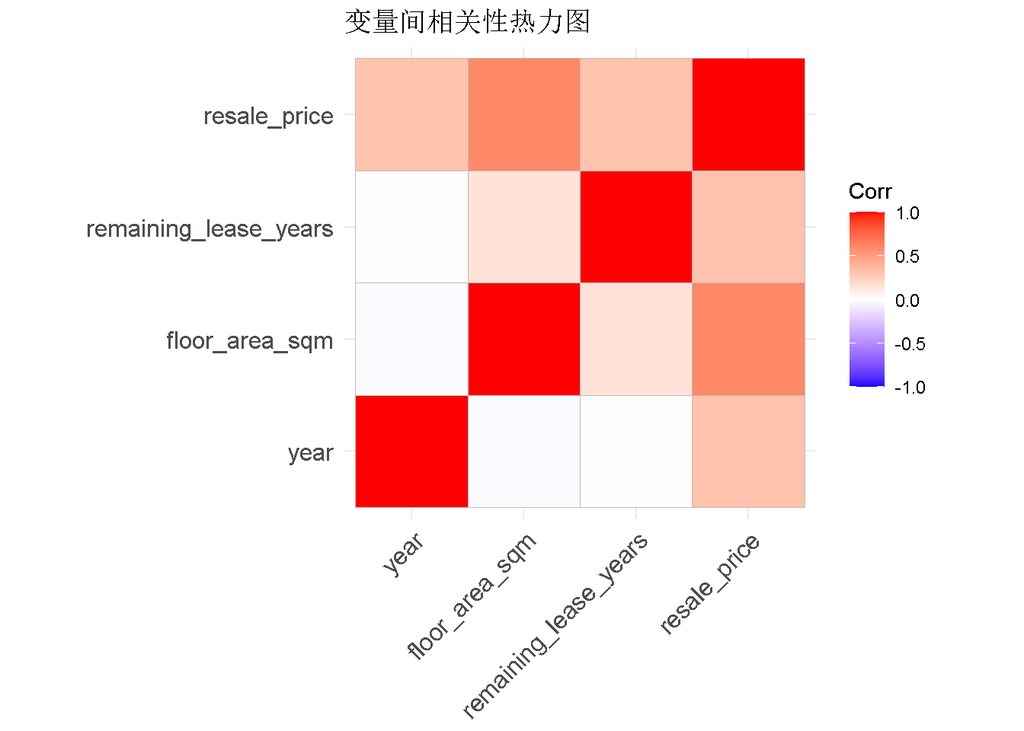

```r
# 加载ggcorrplot库
library(ggcorrplot)
# 热力图：变量间相关性
ggcorrplot(correlation_matrix, title = "变量间相关性热力图")
```

## 模块5：回归分析

### 5.2 数据准备

在进行回归分析之前，我们需要对数据进行一些预处理，包括处理缺失值、转换变量类型等。

```r
# 加载所需库
library(ggplot2)
library(dplyr)

# 读取数据集
data <- read.csv("a.csv")
```

### 5.3 模型构建

我们将使用 lm() 函数来构建1元线性回归模型，预测转售价格。

```r
# 构建多元线性回归模型
model <- lm(resale_price ~ year , data = data)
data$.fitted <- fitted(model)
data$.resid <- residuals(model)
# 查看模型摘要
summary(model)
```

```
##
## Call:
## lm(formula = resale_price ~ year, data = data)
##
## Residuals:
##     Min      1Q  Median      3Q     Max
## -405532 -111964  -27532   81689 1012815
##
## Coefficients:
##               Estimate Std. Error t value Pr(>|t|)
## (Intercept) -3.920e+07  2.539e+05  -154.4   <2e-16 ***
## year         1.965e+04  1.257e+02   156.3   <2e-16 ***
## ---
## Signif. codes:  0 '***' 0.001 '**' 0.01 '*' 0.05 '.' 0.1 ' ' 1
##
## Residual standard error: 161600 on 220969 degrees of freedom
## Multiple R-squared:  0.09959,    Adjusted R-squared:  0.09958
## F-statistic: 2.444e+04 on 1 and 220969 DF,  p-value: < 2.2e-16
```

### 5.4 模型诊断

在进行回归分析后，我们需要对模型进行诊断，检查是否存在违反回归假设的情况。

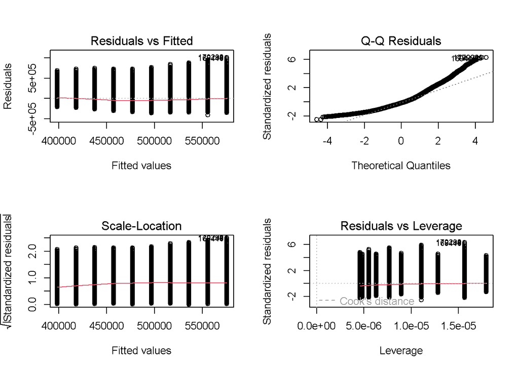

```r
# 模型诊断图
par(mfrow = c(2, 2))
plot(model)
```

### 5.5 回归分析

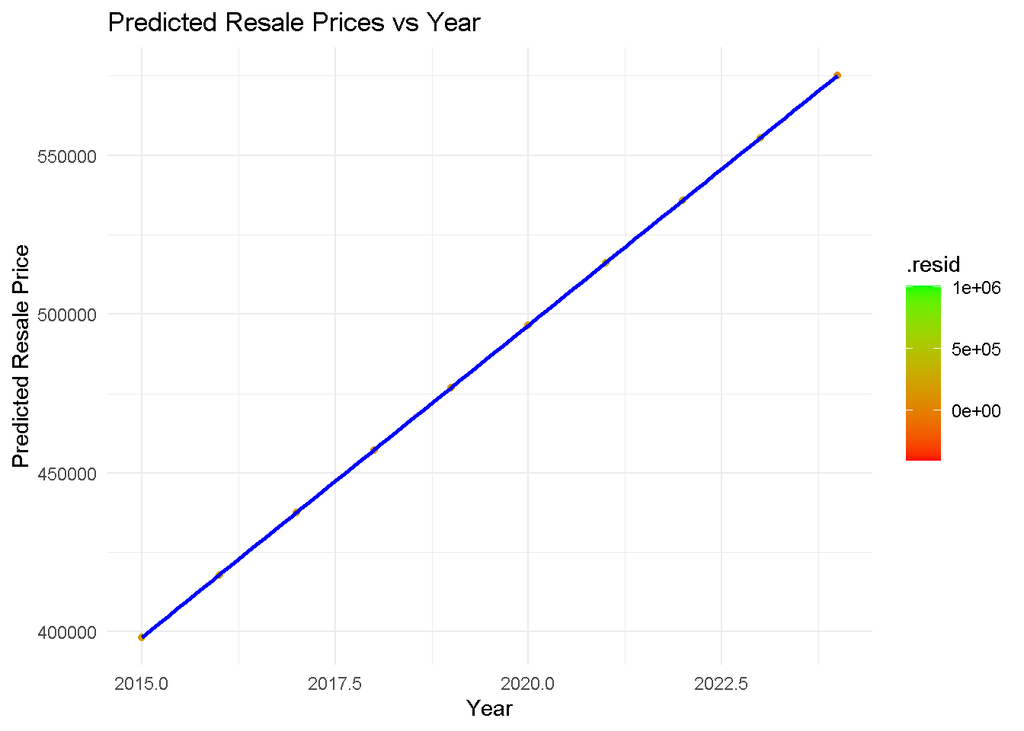

```r
# 预测值与年份的关系图
ggplot(data, aes(x = year, y = .fitted)) +  # 使用 .fitted 代表预测值
  geom_point(aes(color = .resid), alpha = 0.5) +  # 使用 .resid 代表残差
  geom_smooth(method = "lm", se = FALSE, color = "blue") +  # 添加线性回归线
  ggtitle("Predicted Resale Prices vs Year") +
  xlab("Year") +
  ylab("Predicted Resale Price") +
  theme_minimal() +
  scale_color_gradient(low = "red", high = "green")  # 残差颜色梯度
```

## 模块6：分类分析

### 6.1 分类目标

根据价格区间对组屋进行分类。我们将使用决策树或随机森林模型来预测组屋的价格区间。

### 6.2 数据准备

将价格变量转换成分类变量，以便进行分类分析。

```r
# 检查data$price的类型
class(data$resale_price)
```

```
## [1] "numeric"
```

```r
# 如果data$price不是数值型，尝试将其转换为数值型
data$resale_price <- as.numeric(data$resale_price)

# 检查转换后是否有NA值
sum(is.na(data$resale_price))
```

```
## [1] 0
```

```r
# 如果有必要，处理NA值，例如通过删除或替换
# data$resale_price <- na.omit(data$resale_price) # 删除含有NA的行
# 或者
# data$resale_price[is.na(data$resale_price)] <- median(data$resale_price, na.rm = TRUE) # 用中位数替换NA

# 再次执行分类变量的转换
data$price_category <- cut(data$resale_price,
                           breaks = quantile(data$resale_price, probs = c(0, 0.25, 0.5, 0.75, 1), na.rm = TRUE),
                           labels = c("Low", "Medium", "High", "Very High"),
                           include.lowest = TRUE)

# 检查结果
table(data$price_category)
```

```
##
##       Low    Medium      High Very High
##     55504     55388     55718     54361
```

### 6.3 模型选择

选择决策树或随机森林模型进行分类。

### 6.4随机森林模型

使用随机森林模型进行分类，并可视化特征重要性。

```r
library(randomForest)
# 创建随机森林模型
set.seed(123) # 设置随机种子以获得可重现的结果
rf_model <- randomForest(price_category ~ ., data = data)

# 可视化特征重要性
importance(rf_model)
```

```
##                          MeanDecreaseGini
## year                            6655.5662
## town                             771.8266
## flat_type                       6546.0227
## block                            301.3330
## street_name                      497.0510
## storey_range                     808.4093
## floor_area_sqm                  8715.9670
## remaining_lease_years           2280.7736
## resale_price                   93423.3313
## storey_range_category            258.1282
## distance_from_expressway          30.4179
## .fitted                         6053.1941
## .resid                         39332.6227
```

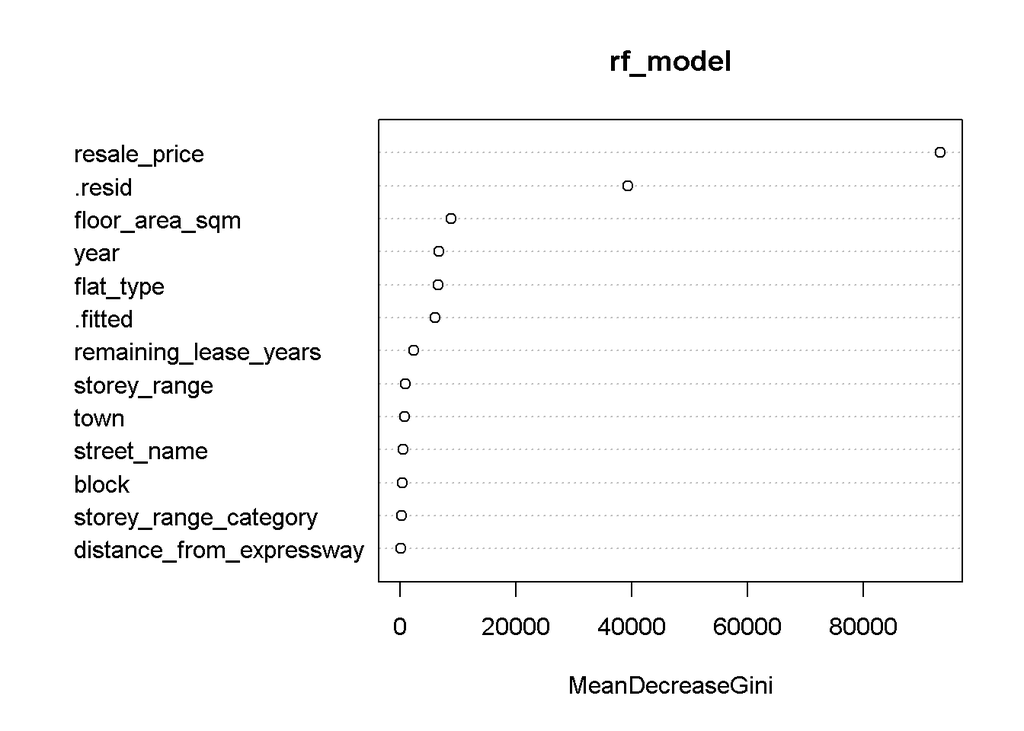

```r
varImpPlot(rf_model)
```

## 模块7 总结：

### 7.2展望与未来工作

在未来，将进一步优化模型，引入更多的动态变量，如经济指标、政策变动等，以提高预测精度。此外，探索实时更新的预测系统也是我们的研究方向之一，以期为客户提供即时、准确的房价参考。